# Composition Analysis of the Estonian National Bibliography dated 2025-07-05

# Overall summary

408,867 records and 44,253,187 attribute values in total. Constituent files:

- data/erb/erb.parquet (113MB)

## Temporal overview

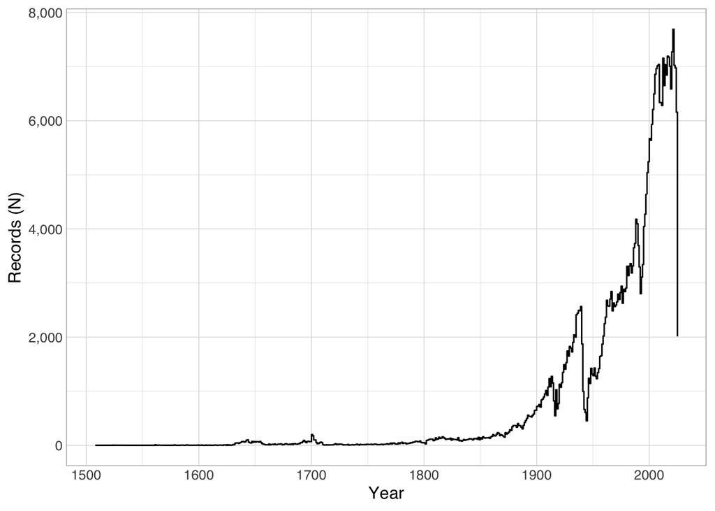

4,171 records do not have easily parseable dates between the years 1000 and 2050.

## Language overview

| [] | Records (N) | Proportion (%) |
| --- | --- | --- |
| est (Estonian) | 292387 | 0.715113435142882 |
| rus (Russian) | 47844 | 0.117015760587769 |
| eng (English) | 25447 | 0.0622376904037489 |
| ger (German) | 21009 | 0.0513833315397634 |
| zxx (No linguistic content; Not applicable) | 8411 | 0.0205714313666024 |
| lat (Latin) | 4202 | 0.0102771554633769 |
| fin (Finnish) | 2644 | 0.00646663470851228 |
| swe (Swedish) | 1904 | 0.00465675963880764 |
| fre (French) | 938 | 0.0022941389397067 |
| lav (Latvian) | 857 | 0.00209603099288768 |

[output cut: 98 more lines]

# Field code usage overview

In total, 203 distinct fields are used.

Legend for the table below:

- `records`: how many records have at least one of this field
- `r_p`: the above as a percentage of all records
- `n`: the total number of appearances of this field
- `vals_per_rec`: calculated from the above, the mean number of appearances of this field per record
- `recs_with_mult_vals`: the number of records that have more than one repetition of this field

| field_code | field_description | records | r_p | n | vals_per_rec | recs_with_mult_vals |
| --- | --- | --- | --- | --- | --- | --- |
| <a name="001" href="https://www.loc.gov/marc/bibliographic/bd001.html">001</a> | Control Number | 408867 | 1 | 408867 | 1 | 0 |
| <a name="003" href="https://www.loc.gov/marc/bibliographic/bd003.html">003</a> | Control Number Identifier | 408867 | 1 | 408867 | 1 | 0 |
| <a name="006" href="https://www.loc.gov/marc/bibliographic/bd006.html">006</a> | Additional Material Characteristics | 135111 | 0.330452200837925 | 135534 | 1.00313075915358 | 405 |
| <a name="007" href="https://www.loc.gov/marc/bibliographic/bd007.html">007</a> | Physical Description | 163104 | 0.398917007241964 | 191458 | 1.17384000392388 | 28299 |
| <a name="008" href="https://www.loc.gov/marc/bibliographic/bd008.html">008</a> | General Information | 408867 | 1 | 408868 | 1.0000024457831 | 1 |
| <a name="010" href="https://www.loc.gov/marc/bibliographic/bd010.html">010</a> | Library of Congress Control Number | 23 | 5.62530113704456e-05 | 23 | 1 | 0 |
| <a name="015" href="https://www.loc.gov/marc/bibliographic/bd015.html">015</a> | National Bibliography Number | 2 | 4.89156620612571e-06 | 2 | 1 | 0 |
| <a name="020" href="https://www.loc.gov/marc/bibliographic/bd020.html">020</a> | International Standard Book Number | 188187 | 0.460264584816089 | 343295 | 1.82422271464022 | 127367 |
| <a name="022" href="https://www.loc.gov/marc/bibliographic/bd022.html">022</a> | International Standard Serial Number | 5913 | 0.0144619154884107 | 6949 | 1.17520717064096 | 1015 |
| <a name="023" href="https://www.loc.gov/marc/bibliographic/bd020.html">023</a> | Cluster ISSN | 1 | 2.44578310306285e-06 | 3 | 3 | 1 |

[output cut: 193 more lines]

# Field code usage overview by subfield

In total, 1,083 distinct field+subfield combinations are used.

Legend for the table below:

- `records`: how many records have at least one of this field+subfield
- `r_p`: the above as a percentage of all records
- `dist_vals`: the number of different values appearing in this field+subfield
- `e_vals`: at most seven random sample values of this field+subfield
- `n`: the total number of appearances of this field+subfield
- `vals_per_rec`: calculated from the above, the mean number of appearances of this field+subfield per record
- `recs_with_mult_vals`: the number of records that have more than one repetition of this field+subfield

| subfield_code | subfield_description | records | r_p | dist_vals | e_vals | n | vals_per_rec | recs_with_mult_vals |
| --- | --- | --- | --- | --- | --- | --- | --- | --- |
| [001: Control Number](https://www.loc.gov/marc/bibliographic/bd001.html) |  |  |  |  |  |  |  |  |
| 001$ | NA | 408,867 | 100% | 408,867 | b13887580 (1)\|b26518764 (1)\|b15317018 (1)\|b17088355 (1)\|b28589932 (1)\|b11852410 (1)\|b15624948 (1) | 408,867 | 1 | 0 |
| [003: Control Number Identifier](https://www.loc.gov/marc/bibliographic/bd003.html) |  |  |  |  |  |  |  |  |
| 003$ | NA | 408,867 | 100% | 1 | ErRR (408867) | 408,867 | 1 | 0 |
| [006: Additional Material Characteristics](https://www.loc.gov/marc/bibliographic/bd006.html) |  |  |  |  |  |  |  |  |
| 006$ | NA | 135,111 | 33.05% | 285 | m \| 4d \| (1)\|m \| d\|\| (2)\|j\|\|\|\|\|\|\|\|\|\|\|\|\| (4)\|c (15)\|g037 \| \| vl (1)\|g120 \| \| v\| (1)\|e\|\|\|\| g \|\|1 \|\| (1) | 135,534 | 1 | 405 |
| [007: Physical Description](https://www.loc.gov/marc/bibliographic/bd007.html) |  |  |  |  |  |  |  |  |
| 007$ | NA | 163,104 | 39.89% | 569 | ss lmujlnauuau (4)\|vf \|b\|hos (1)\|aj cau\|\| (10)\|aj cf\|\|\| (2)\|sd cmmennmpl\|e (2)\|ss lmnjlnauuau (2)\|vf cbahoq (6) | 191,458 | 1.17 | 28,299 |
| [008: General Information](https://www.loc.gov/marc/bibliographic/bd008.html) |  |  |  |  |  |  |  |  |
| 008$ | NA | 408,867 | 100% | 216,173 | 030210s1892 er ab \| \|\|\|\|\|\|\|\| 0\|rus (1)\|120411d20112014er a \| \| fin (1)\|140206s2013 er \|\|\|\|\|\|\|\|\|\|\|\|\|\| \| est (1)\|090129s2009 er \|\|\|\|\| \|\|\|\|\|\|\|\| 0\|rus (1)\|0705… | 408,868 | 1 | 1 |
| [010: Library of Congress Control Number](https://www.loc.gov/marc/bibliographic/bd010.html) |  |  |  |  |  |  |  |  |
| 010$a | LC control number | 23 | 0.01% | 23 | 98074641 (1)\|73116888 (1)\|91039140 (1)\|a 54006749 (1)\|96090942 (1)\|93044876 (1)\|94018609 (1) | 23 | 1 | 0 |
| [015: National Bibliography Number](https://www.loc.gov/marc/bibliographic/bd015.html) |  |  |  |  |  |  |  |  |
| 015$a | National bibliography number | 2 | 0% | 2 | urn:nbn:ee-b10544215 (1)\|R1997-123 (1) | 2 | 1 | 0 |
| [020: International Standard Book Number](https://www.loc.gov/marc/bibliographic/bd020.html) |  |  |  |  |  |  |  |  |
| 020$Y | NA | 1 | 0% | 1 | 3 (1) | 1 | 1 | 0 |
| 020$Z | NA | 1 | 0% | 1 | 9 (1) | 1 | 1 | 0 |
| 020$a | International Standard Book Number | 188,021 | 45.99% | 205,621 | 9789949308996 (1)\|9985762525 (1)\|9789949337811 (1)\|9789985329030 (1)\|9789916550502 (1)\|9985763912 (1)\|9789916091531 (1) | 208,360 | 1.11 | 18,806 |
| 020$c | Terms of availability | 7 | 0% | 6 | tasuta (2)\|(CD) (1)\|riputusliistudega (2)\|(pdf) (1)\|(epub) (1)\|18 EUR (1) | 8 | 1.14 | 1 |
| 020$q | NA | 123,483 | 30.2% | 1,402 | (kassett 1) (2)\|(39. kd.) (1)\|1.vihik (1)\|vol. 4) (2)\|(75. osa) (1)\|(MP3) (2)\|(soft cover) (1) | 132,727 | 1.07 | 6,298 |
| 020$z | Cancelled/invalid ISBN | 2,140 | 0.52% | 1,975 | 9789949453023 (1)\|9789985975350 (2)\|9985889037 (1)\|9985823087 (2)\|9985004046 (1)\|9949133588 (1)\|9789949433186 (1) | 2,198 | 1.03 | 57 |
| [022: International Standard Serial Number](https://www.loc.gov/marc/bibliographic/bd022.html) |  |  |  |  |  |  |  |  |
| 022$Y | NA | 920 | 0.23% | 2 | 1 (2)\|0 (919) | 921 | 1 | 1 |
| 022$a | International Standard Serial Number | 5,910 | 1.45% | 5,908 | 1736-0633 (1)\|3059-6688 (1)\|1736-8723 (1)\|2461-3614 (1)\|2461-1654 (1)\|2613-5159 (1)\|2504-7299 (1) | 5,912 | 1 | 2 |
| 022$l | NA | 37 | 0.01% | 30 | 1406-6254 (2)\|1406-6319 (2)\|2346-6332 (2)\|1736-9851 (1)\|2346-6413 (1)\|2346-6626 (1)\|2228-4508 (1) | 37 | 1 | 0 |
| 022$y | Incorrect ISSN | 11 | 0% | 13 | 0273-3293 (1)\|1092-1425 (1)\|2585-674X (1)\|0206-5195 (1)\|0282-2008 (1)\|0134-3823 (1)\|0135-2482 (1) | 13 | 1.18 | 1 |
| 022$z | Cancelled ISSN | 64 | 0.02% | 66 | 0131-6079 (1)\|1406-3905 (1)\|0868-6181 (1)\|1018-7669 (1)\|0135-2466 (1)\|0474-7321 (tühistatud) (1)\|1736-6100 (1) | 66 | 1.03 | 2 |
| [023: Cluster ISSN](https://www.loc.gov/marc/bibliographic/bd020.html) |  |  |  |  |  |  |  |  |
| 023$Y | NA | 1 | 0% | 1 | 9 (1) | 1 | 1 | 0 |
| 023$Z | NA | 1 | 0% | 1 | 9 (1) | 1 | 1 | 0 |

[output cut: 1256 more lines]